### Introduction

The dataset is **Loan Data From Prosper**

This data set contains 113,937 loans with 81 variables on each loan, including loan amount, borrower rate (or interest rate), current loan status, borrower income, and many others.

```python
#importing the propor liabilities
import pandas as pd
import numpy as np
import matplotlib.pyplot as plt
import seaborn as sns

#Reading the file

df = pd.read_csv('C:/Users/LAPTOP/OneDrive/Desktop/prosperLoanData.csv')

#Looking at the data
df.head(5)
```

|  | ListingKey | ListingNumber | ListingCreationDate | CreditGrade | Term | LoanStatus | ClosedDate | BorrowerAPR | BorrowerRate | LenderYield | ... | LP_ServiceFees | LP_CollectionFees | LP_GrossPrincipalLoss | LP_NetPrincipalLoss | LP_NonPrincipalRecoverypayments | PercentFunded | Recommendations | InvestmentFromFriendsCount | InvestmentFromFriendsAmount | Investors |
| --- | --- | --- | --- | --- | --- | --- | --- | --- | --- | --- | --- | --- | --- | --- | --- | --- | --- | --- | --- | --- | --- |
| 0 | 1021339766868145413AB3B | 193129 | 2007-08-26 19:09:29.263000000 | C | 36 | Completed | 2009-08-14 00:00:00 | 0.16516 | 0.1580 | 0.1380 | ... | -133.18 | 0.0 | 0.0 | 0.0 | 0.0 | 1.0 | 0 | 0 | 0.0 | 258 |
| 1 | 10273602499503308B223C1 | 1209647 | 2014-02-27 08:28:07.900000000 | NaN | 36 | Current | NaN | 0.12016 | 0.0920 | 0.0820 | ... | 0.00 | 0.0 | 0.0 | 0.0 | 0.0 | 1.0 | 0 | 0 | 0.0 | 1 |
| 2 | 0EE9337825851032864889A | 81716 | 2007-01-05 15:00:47.090000000 | HR | 36 | Completed | 2009-12-17 00:00:00 | 0.28269 | 0.2750 | 0.2400 | ... | -24.20 | 0.0 | 0.0 | 0.0 | 0.0 | 1.0 | 0 | 0 | 0.0 | 41 |
| 3 | 0EF5356002482715299901A | 658116 | 2012-10-22 11:02:35.010000000 | NaN | 36 | Current | NaN | 0.12528 | 0.0974 | 0.0874 | ... | -108.01 | 0.0 | 0.0 | 0.0 | 0.0 | 1.0 | 0 | 0 | 0.0 | 158 |
| 4 | 0F023589499656230C5E3E2 | 909464 | 2013-09-14 18:38:39.097000000 | NaN | 36 | Current | NaN | 0.24614 | 0.2085 | 0.1985 | ... | -60.27 | 0.0 | 0.0 | 0.0 | 0.0 | 1.0 | 0 | 0 | 0.0 | 20 |

5 rows × 81 columns

```python
# Looking at the data descriptive summary
df.describe()
```

|  | ListingNumber | Term | BorrowerAPR | BorrowerRate | LenderYield | EstimatedEffectiveYield | EstimatedLoss | EstimatedReturn | ProsperRating (numeric) | ProsperScore | ... | LP_ServiceFees | LP_CollectionFees | LP_GrossPrincipalLoss | LP_NetPrincipalLoss | LP_NonPrincipalRecoverypayments | PercentFunded | Recommendations | InvestmentFromFriendsCount | InvestmentFromFriendsAmount | Investors |
| --- | --- | --- | --- | --- | --- | --- | --- | --- | --- | --- | --- | --- | --- | --- | --- | --- | --- | --- | --- | --- | --- |
| count | 1.139370e+05 | 113937.000000 | 113912.000000 | 113937.000000 | 113937.000000 | 84853.000000 | 84853.000000 | 84853.000000 | 84853.000000 | 84853.000000 | ... | 113937.000000 | 113937.000000 | 113937.000000 | 113937.000000 | 113937.000000 | 113937.000000 | 113937.000000 | 113937.000000 | 113937.000000 | 113937.000000 |
| mean | 6.278857e+05 | 40.830248 | 0.218828 | 0.192764 | 0.182701 | 0.168661 | 0.080306 | 0.096068 | 4.072243 | 5.950067 | ... | -54.725641 | -14.242698 | 700.446342 | 681.420499 | 25.142686 | 0.998584 | 0.048027 | 0.023460 | 16.550751 | 80.475228 |
| std | 3.280762e+05 | 10.436212 | 0.080364 | 0.074818 | 0.074516 | 0.068467 | 0.046764 | 0.030403 | 1.673227 | 2.376501 | ... | 60.675425 | 109.232758 | 2388.513831 | 2357.167068 | 275.657937 | 0.017919 | 0.332353 | 0.232412 | 294.545422 | 103.239020 |
| min | 4.000000e+00 | 12.000000 | 0.006530 | 0.000000 | -0.010000 | -0.182700 | 0.004900 | -0.182700 | 1.000000 | 1.000000 | ... | -664.870000 | -9274.750000 | -94.200000 | -954.550000 | 0.000000 | 0.700000 | 0.000000 | 0.000000 | 0.000000 | 1.000000 |
| 25% | 4.009190e+05 | 36.000000 | 0.156290 | 0.134000 | 0.124200 | 0.115670 | 0.042400 | 0.074080 | 3.000000 | 4.000000 | ... | -73.180000 | 0.000000 | 0.000000 | 0.000000 | 0.000000 | 1.000000 | 0.000000 | 0.000000 | 0.000000 | 2.000000 |
| 50% | 6.005540e+05 | 36.000000 | 0.209760 | 0.184000 | 0.173000 | 0.161500 | 0.072400 | 0.091700 | 4.000000 | 6.000000 | ... | -34.440000 | 0.000000 | 0.000000 | 0.000000 | 0.000000 | 1.000000 | 0.000000 | 0.000000 | 0.000000 | 44.000000 |
| 75% | 8.926340e+05 | 36.000000 | 0.283810 | 0.250000 | 0.240000 | 0.224300 | 0.112000 | 0.116600 | 5.000000 | 8.000000 | ... | -13.920000 | 0.000000 | 0.000000 | 0.000000 | 0.000000 | 1.000000 | 0.000000 | 0.000000 | 0.000000 | 115.000000 |
| max | 1.255725e+06 | 60.000000 | 0.512290 | 0.497500 | 0.492500 | 0.319900 | 0.366000 | 0.283700 | 7.000000 | 11.000000 | ... | 32.060000 | 0.000000 | 25000.000000 | 25000.000000 | 21117.900000 | 1.012500 | 39.000000 | 33.000000 | 25000.000000 | 1189.000000 |

8 rows × 61 columns

```python
# Looking at the number of columns and rows
df.shape
```

```
(113937, 81)
```

### What is the main feature(s) of interest in your dataset?

Is to address the questions about this dataset

1 - What factors affect a loan’s outcome status?

2 - What affects the borrower’s APR or interest rate?

3 - Are there differences between loans depending on how large the original loan amount was?

### The focus would be on:

**1** - LoanSatus

**2** - BorrowerAPR

**3** - LoanOriginalAmount

**4** - StatedMonthlyIncome

### What is/are the main feature(s) of interest in your dataset?

**The columns that i have decided to work with**

1 - Term

2 - LoanStatus

3 - BorrowerAPR

4 - EstimatedReturn

5 - Occupation

6 - EmploymentStatus

7 - LoanOriginalAmount

8 - StatedMonthlyIncome

### Wrangling Process

```python
# getting the columns names
df.columns
```

```
Index(['ListingKey', 'ListingNumber', 'ListingCreationDate', 'CreditGrade',
       'Term', 'LoanStatus', 'ClosedDate', 'BorrowerAPR', 'BorrowerRate',
       'LenderYield', 'EstimatedEffectiveYield', 'EstimatedLoss',
       'EstimatedReturn', 'ProsperRating (numeric)', 'ProsperRating (Alpha)',
       'ProsperScore', 'ListingCategory (numeric)', 'BorrowerState',
       'Occupation', 'EmploymentStatus', 'EmploymentStatusDuration',
       'IsBorrowerHomeowner', 'CurrentlyInGroup', 'GroupKey',
       'DateCreditPulled', 'CreditScoreRangeLower', 'CreditScoreRangeUpper',
       'FirstRecordedCreditLine', 'CurrentCreditLines', 'OpenCreditLines',
       'TotalCreditLinespast7years', 'OpenRevolvingAccounts',
       'OpenRevolvingMonthlyPayment', 'InquiriesLast6Months', 'TotalInquiries',
       'CurrentDelinquencies', 'AmountDelinquent', 'DelinquenciesLast7Years',
       'PublicRecordsLast10Years', 'PublicRecordsLast12Months',
       'RevolvingCreditBalance', 'BankcardUtilization',
       'AvailableBankcardCredit', 'TotalTrades',
       'TradesNeverDelinquent (percentage)', 'TradesOpenedLast6Months',
       'DebtToIncomeRatio', 'IncomeRange', 'IncomeVerifiable',
       'StatedMonthlyIncome', 'LoanKey', 'TotalProsperLoans',
       'TotalProsperPaymentsBilled', 'OnTimeProsperPayments',
       'ProsperPaymentsLessThanOneMonthLate',
       'ProsperPaymentsOneMonthPlusLate', 'ProsperPrincipalBorrowed',
       'ProsperPrincipalOutstanding', 'ScorexChangeAtTimeOfListing',
       'LoanCurrentDaysDelinquent', 'LoanFirstDefaultedCycleNumber',
       'LoanMonthsSinceOrigination', 'LoanNumber', 'LoanOriginalAmount',
       'LoanOriginationDate', 'LoanOriginationQuarter', 'MemberKey',
       'MonthlyLoanPayment', 'LP_CustomerPayments',
       'LP_CustomerPrincipalPayments', 'LP_InterestandFees', 'LP_ServiceFees',
       'LP_CollectionFees', 'LP_GrossPrincipalLoss', 'LP_NetPrincipalLoss',
       'LP_NonPrincipalRecoverypayments', 'PercentFunded', 'Recommendations',
       'InvestmentFromFriendsCount', 'InvestmentFromFriendsAmount',
       'Investors'],
      dtype='object')
```

```python
# First i am looking for the columns which are important and relevent to the questions
# Then removing the rest of the other columns

df.drop(df.columns.difference(['Term', 'LoanStatus', 'BorrowerAPR', 'EstimatedReturn', 'Occupation', 'EmploymentStatus', 'LoanOriginalAmount', 'StatedMonthlyIncome']), axis = 1, inplace = True)
```

```python
# Reading the new dataset after removing the unwanted columns
df.head(5)
```

|  | Term | LoanStatus | BorrowerAPR | EstimatedReturn | Occupation | EmploymentStatus | StatedMonthlyIncome | LoanOriginalAmount |
| --- | --- | --- | --- | --- | --- | --- | --- | --- |
| 0 | 36 | Completed | 0.16516 | NaN | Other | Self-employed | 3083.333333 | 9425 |
| 1 | 36 | Current | 0.12016 | 0.05470 | Professional | Employed | 6125.000000 | 10000 |
| 2 | 36 | Completed | 0.28269 | NaN | Other | Not available | 2083.333333 | 3001 |
| 3 | 36 | Current | 0.12528 | 0.06000 | Skilled Labor | Employed | 2875.000000 | 10000 |
| 4 | 36 | Current | 0.24614 | 0.09066 | Executive | Employed | 9583.333333 | 15000 |

```python
# Converting Stated Monthly Income into an Int
df['StatedMonthlyIncome'] = df['StatedMonthlyIncome'].astype(int)
```

### Getting rid of the NaN values

```python
df.isnull().any()
```

```
Term                   False
LoanStatus             False
BorrowerAPR             True
EstimatedReturn         True
Occupation              True
EmploymentStatus        True
StatedMonthlyIncome    False
LoanOriginalAmount     False
dtype: bool
```

```python
df = df.dropna(subset=['BorrowerAPR', 'Occupation', 'EmploymentStatus'])
```

```python
df['EstimatedReturn'].isnull().sum().sum()
```

```
26829
```

```python
# Since the EstimatedReturn has a high number of NaN values so i will convert the NaN values into the mean
df['EstimatedReturn'] = df['EstimatedReturn'].fillna(df['EstimatedReturn'].mean())
```

```python
# Checking if there is still NaN value
df.isnull().any()
```

```
Term                   False
LoanStatus             False
BorrowerAPR            False
EstimatedReturn        False
Occupation             False
EmploymentStatus       False
StatedMonthlyIncome    False
LoanOriginalAmount     False
dtype: bool
```

### Univariate Exploration

In this part i would investigate a single column in a certain chart in order to get some insights regarding the chosen column

using several plots such as Hist or Countplot

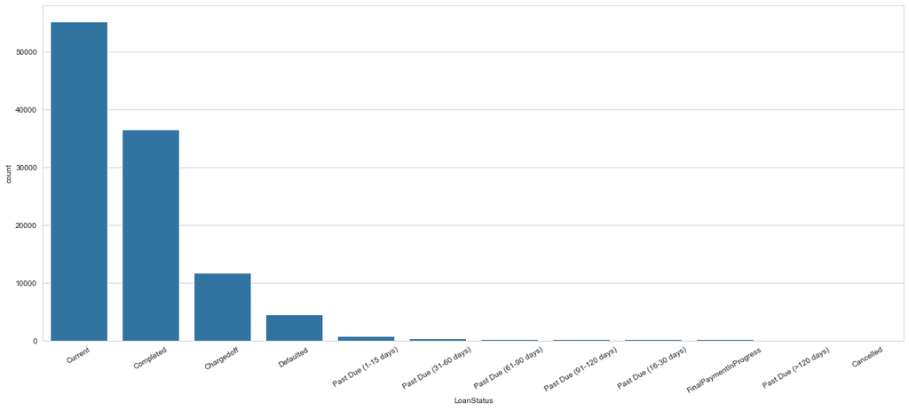

```python
# Looking at the count number of LoanStatus
# Adjusting the colors and the size and the order of the figure
plt.figure(figsize=[20, 8])
color_base = sns.color_palette()[0]
order = df['LoanStatus'].value_counts().index


# Plotting the chart
sns.countplot(data = df, x = df['LoanStatus'], order = order, color = color_base);
plt.xticks(rotation = 30);
```

### interpretation

as it seems from the figure the highest number is **Current** which is above 50k

and that means loan that is fully paid up to date according to a contract

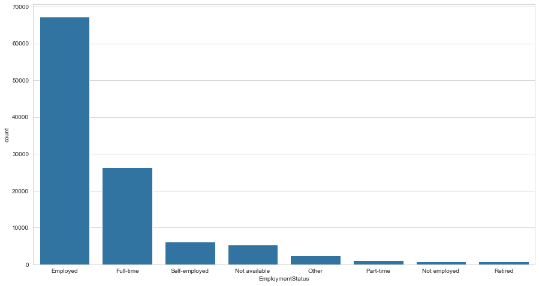

```python
# Looking at the count number of EmploymentStatus
# Adjusting the colors and the size and the order of the figure
plt.figure(figsize=[15, 8])
color_base = sns.color_palette()[0]
order = df['EmploymentStatus'].value_counts().index

# Plotting the figure
sns.countplot(df['EmploymentStatus'], order = order, color = color_base);
```

### interpretation

based on the figure, the majority of people who had got loans already **employed**

which means they should be able to pay for their loans but it'll be based on the monthly income

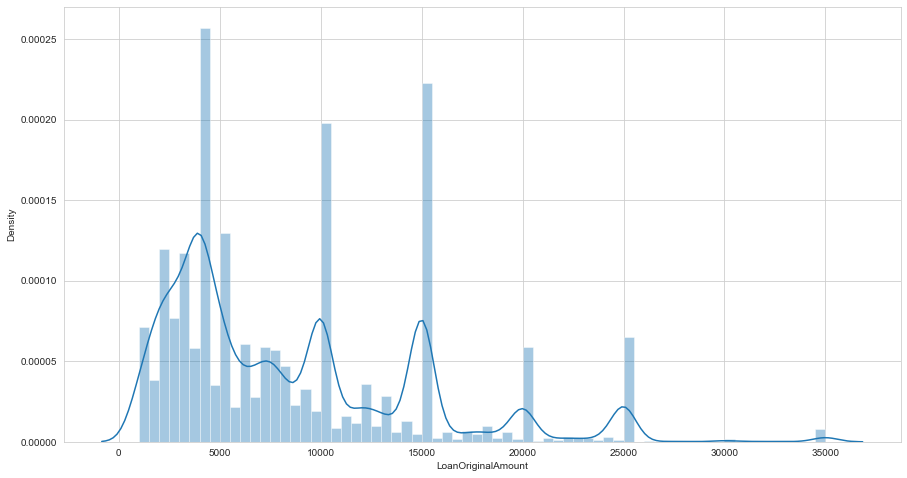

```python
# Checking the disturbution of the Loan Original Amount
plt.figure(figsize=[15, 8])
# Adjusting the number of bins so i could get accurate insights
bins = np.arange(1000, df['LoanOriginalAmount'].max()+100, 500)

# PLotting the histogram
sns.distplot(df['LoanOriginalAmount'], bins = bins);
```

### interpretation

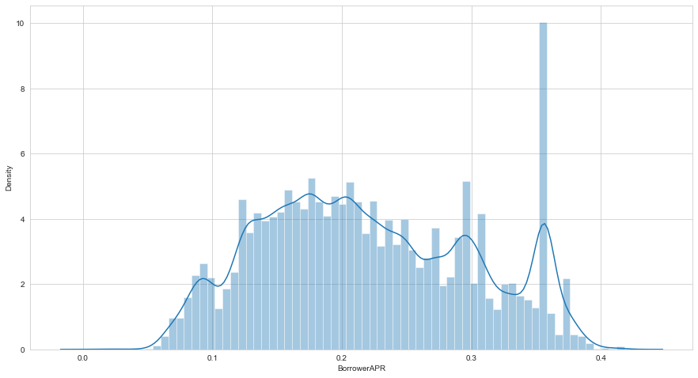

```python
# Checking the distribution of BorrowerAPR
plt.figure(figsize=[15, 8])

# PLotting the histogram
sns.distplot(df['BorrowerAPR'], bins = 70);
```

### interpretation

i had the maximize the number of bins so i could get a clear look at the distribution

i can't tell for sure the if the distribution is left skewed or normal distribution

### Bivariate Exploration

Trying to get more accurate results by finding a correlation between observations or doing compressions between of them

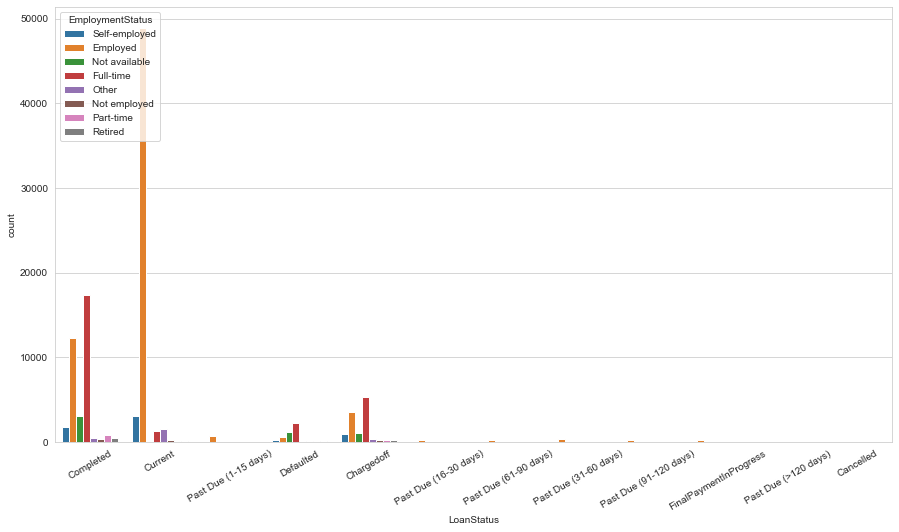

```python
# I am looking for a co
plt.figure(figsize=[15, 8])

# Plotting the Figure
sns.countplot(data = df, x = 'LoanStatus', hue = 'EmploymentStatus');
plt.xticks(rotation = 30);
```

### interpretation

It shows that the **Current** Loan Status has the highest number of employed people

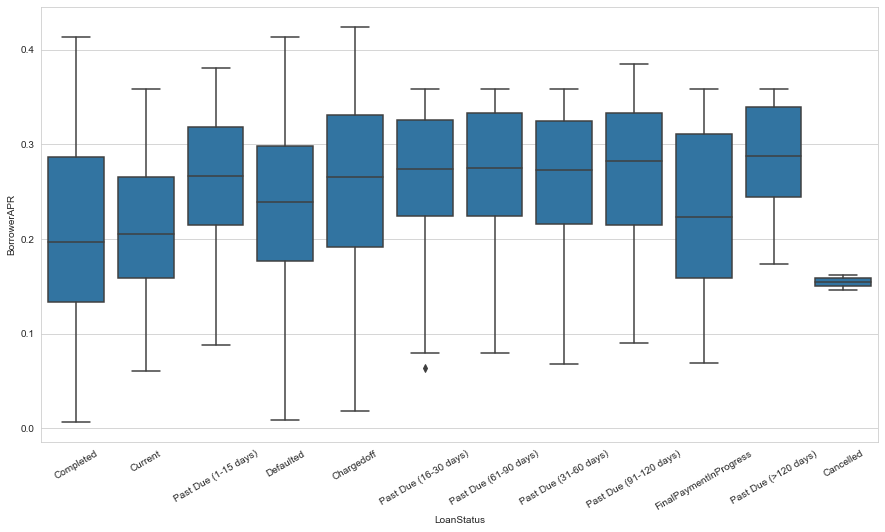

```python
# Plotting a boxplot between LoanStatus and BorrowerAPR
plt.figure(figsize=[15, 8])
color = sns.color_palette()[0]
# Plotting the boxplot
sns.boxplot(data = df, x = 'LoanStatus', y = 'BorrowerAPR', color = color);
plt.xticks(rotation = 30);
```

### Multivariate Exploration

```
 Drawing plots using more than two variables and looking for the relationship between of them
```

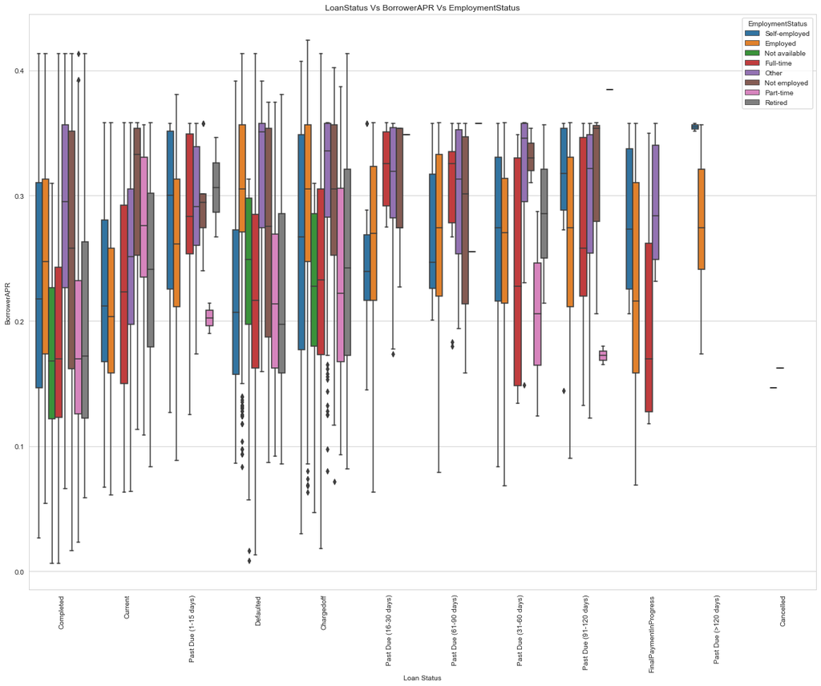

```python
# I could use three variable but since the columns i have decided to work with are limted
# then i would work with borrowerAPR, employmentstatus and loanstatus
plt.figure(figsize=[20,15])


# plotting the boxplot
sns.boxplot(data=df, x="LoanStatus", y = "BorrowerAPR", hue = 'EmploymentStatus');
plt.xticks(rotation = 90);
plt.title('LoanStatus Vs BorrowerAPR Vs EmploymentStatus');
plt.xlabel('Loan Status');
plt.ylabel('BorrowerAPR');
```

### interpretation

**2**- The lowest value of BorrowAPR Full Time

```python
df.head(2)
```

|  | Term | LoanStatus | BorrowerAPR | EstimatedReturn | Occupation | EmploymentStatus | StatedMonthlyIncome | LoanOriginalAmount |
| --- | --- | --- | --- | --- | --- | --- | --- | --- |
| 0 | 36 | Completed | 0.16516 | 0.096301 | Other | Self-employed | 3083 | 9425 |
| 1 | 36 | Current | 0.12016 | 0.054700 | Professional | Employed | 6125 | 10000 |

### What factors affect a loan’s outcome status?

Based on the figures and the draws so far i could say BorrowerAPR alongside with EmploymentStatus

### What affects the borrower’s APR or interest rate?

so the factor that affects the Borrower's APR is LoanStatus and EmploymentStatus

but that's based on that i have decided to work with observations

there're might could be other columns which influnce this certain column but i have not chosen it

### Conclusion:

Regarding to **Univariate Exploration**:

i created several figures cause i wanted to see the insights from almost every single observation that i got so we could say

1 - The highest loan status is current which is above 50k

2 - The majority of people who got loans are already working

Regarding to **Bivariate Analysis**

i have created two plots to look at the correlation between of them

1 - The current loan status, it has the highest number of people who are working or employed

Regarding to **Multivariate Analysis**

```python
# Saving the file
df.to_csv('df.csv', index=False)
```